# Probability-Introduction

Seoncheol Park

25/11/2019

다음의 책을 참고하였다.

- Probability and Measure, Patrick Billingsley (PB)
- [Probability, Theory and Examples, Rick Durrett](https://services.math.duke.edu/~rtd/PTE/PTE5_011119.pdf) (RD)
- Essential of Probability Theory for Statistician
- Probability Essentials, Jean Jacod and Philip Protter (JP)
- Probability for Statisticians, Galen R. Shorack (GS)
- Probability: A Graduate Course, Allan Gut (AG)
- Analysis, Measure, and Probability: A visual introduction
- Counterexamples in Probability, Jordan M. Stoyanov (JS)

# 1 확률론의 기본적인 아이디어

## 1.1 사이즈의 개념

(Pivato 2003)

(Cardinality, length, area, volume, frequency 그리고 probability)

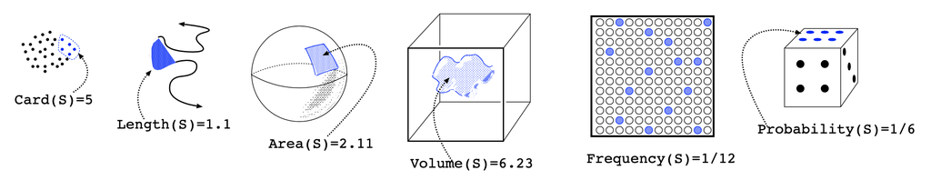

Cardinality, length, area, volume, frequency 그리고 probability의 개념

위 그림에서 나오는 Cardinality, length, area, volume, frequency 그리고 probability는 모두 **양(quantity)**를 재기 위해 나온 개념들이다.

## 1.2 Cardinality

(Proschan and Shaw 2018)

어떤 집합 $A$에 대해 $A$의 원소의 갯수를 우리는 **cardinality of** $A$라고 하고 $\text{card}(A)$라고 쓴다.

**Definition 1.1 (Countably infinite, countable, uncountably infinite, uncountable)** 어떤 집합 $A$가 자연수와 일대일 대응일 때 $A$를 **Countably infinite**라고 한다. 그리고 $A$가 유한(finite)하거나 countably infinite일 때 $A$를 **countable**이라고 한다. 그렇지 않은 경우를 각각 **uncountably infinite, uncountable**이라고 부른다.

*Remark.* 앞으로 우리는 확률변수가 이산인 경우와 연속인 경우를 잘 구분해서 생각해야 한다. 이산은 우리가 직관적으로 좀 더 이해하기 쉬운 성질들을 갖고 있다. 반면 연속의 경우 선뜻 이해가 안가는 경우가 생길 것이다.

**Proposition 1.1 (Uncountability of [0,1])** 간격 $[0,1]$은 uncountable하다.

**Proposition 1.2 (A countable union of countable sets is countable)** Countable sets $A_i$들의 countable union $\cup_{i=1}^{\infty}A_{i}$는 countable이다.

*Proof.* (Essential of Probability Theory for Statistician) Proposition 2.6 참고

**Definition 1.2 (Two sets having the same cardinality)** 두 집합 $A$, $B$ 사이에 일대일 대응 관계가 있을 때 이들이 same cardinaility를 갖는다고 말한다.

## 1.3 실수에서의 길이(length)

(Billingsley 2012)

다음과 같이 $a,b\in\mathbb{R}$일 때 ($a<=b$) interval $I$를 $I=(a,b]$와 같이 정의하자. 이 때 $|I|=b-a$는 interval $I$의 길이가 된다.

또한 interval들의 finite 또는 infinite sequence $I_{k}=(a_k, b_k]$를 생각해보자. 각각의 interval들은 bounded라고 가정해보자. 그러면 다음의 정리를 얻는다.

**Theorem 1.1** 1. 만약 $\bigcup_{k}I_{k}\subset I$이고 $I_{k}$들이 disjoint라면, $\sum_{k}|I_k|\leq |I|$이다.

2. 만약 $I \subset\bigcup_{k}I_{k}$ (이 때 $I_{k}$들이 disjoint일 필요는 없다)라면 $|I|\leq \sum_{k}|I_k|$이다.
3. 만약 $I=\bigcup_{k}I_{k}$이고 $I_{k}$들이 disjoint라면, $|I|=\sum_{k}|I_k|$이다.

*Proof.* Billingsley (2012) Theorem 1.3 참고

Billingsley, Patrick. 2012. *Probability and Measure*. 3rd ed. John Wiley; Sons.

Pivato, Marcus. 2003. “Analysis, Measure, and Probability: A Visual Introduction.”

Proschan, Michael A., and Pamela A. Shaw. 2018. *Essentials of Probability Theory for Statisticians*. CRC Press.